# Corrección de batch effect y PCA post-batch del bloque tumoral GEO

TFM Melanoma Inmunoterapia

2026-05-05

# 1 Objetivo

Este documento realiza la corrección exploratoria del efecto batch en el bloque tumoral GEO integrado.

El objetivo es:

1. Cargar el objeto `SummarizedExperiment` tumoral.
2. Revisar las variables clínicas disponibles.
3. Evaluar el balance de respuesta por cohorte/plataforma.
4. Aplicar `limma::removeBatchEffect()` usando la cohorte como batch.
5. Proteger la variable de respuesta (`response_binary`) en el modelo de corrección.
6. Generar PCA post-batch.
7. Comparar visualmente PCA pre-batch y post-batch.
8. Guardar la matriz corregida y el objeto tumoral con un nuevo assay.

> Nota metodológica: esta corrección se plantea para exploración/PCA y análisis diferencial. Para modelos predictivos, conviene comparar estrategias con y sin corrección, o incluir cohorte/plataforma como variable de ajuste.

## 1.1 Ficha del informe

| Elemento | Detalle |
| --- | --- |
| Entrada | `integrated_dataset/se_integrated_geo_tumor.rds` |
| Salida principal | Objeto tumoral con assay `expr_batch_corrected_limma` |
| Carpeta de resultados | `resultados/batch_correction_geo_tumor/` |
| Decision metodologica | Usar `limma::removeBatchEffect()` para exploracion/PCA y DEA, protegiendo `response_binary` |
| Robustez | Comparar resultados con matriz sin corregir ajustando por dataset/plataforma |

# 2 Librerías

```r
required_packages <- c(
  "SummarizedExperiment",
  "dplyr",
  "tibble",
  "ggplot2",
  "knitr",
  "limma",
  "matrixStats",
  "tidyr"
)

for (pkg in required_packages) {
  if (!requireNamespace(pkg, quietly = TRUE)) {
    stop(paste("Falta instalar el paquete:", pkg))
  }
}

library(SummarizedExperiment)
library(dplyr)
library(tibble)
library(ggplot2)
library(knitr)
library(limma)
library(matrixStats)
```

# 3 Localización del objeto tumoral

```r
candidate_paths <- c(
  "C:/Users/sonia/Desktop/2_TFM_MELANOMA/integrated_dataset/se_integrated_geo_tumor.rds",
  "integrated_dataset/se_integrated_geo_tumor.rds",
  "../integrated_dataset/se_integrated_geo_tumor.rds",
  "../../integrated_dataset/se_integrated_geo_tumor.rds",
  "data/processed/integrated_dataset/se_integrated_geo_tumor.rds",
  "../data/processed/integrated_dataset/se_integrated_geo_tumor.rds",
  "../../data/processed/integrated_dataset/se_integrated_geo_tumor.rds",
  "se_integrated_geo_tumor.rds",
  "../se_integrated_geo_tumor.rds",
  "../../se_integrated_geo_tumor.rds"
)

existing_paths <- candidate_paths[file.exists(candidate_paths)]

if (length(existing_paths) == 0) {
  stop(
    "No se ha encontrado el objeto tumoral .rds. ",
    "Revisa la ubicación del archivo generado en el Rmd anterior y actualiza candidate_paths."
  )
}

tumor_path <- existing_paths[1]
tumor_path
```

```
## [1] "C:/Users/sonia/Desktop/2_TFM_MELANOMA/integrated_dataset/se_integrated_geo_tumor.rds"
```

```r
project_root <- normalizePath(file.path(dirname(tumor_path), ".."), winslash = "/", mustWork = FALSE)
project_root
```

```
## [1] "C:/Users/sonia/Desktop/2_TFM_MELANOMA"
```

```r
se_tumor <- readRDS(tumor_path)

stopifnot(inherits(se_tumor, "SummarizedExperiment"))
se_tumor
```

```
## class: SummarizedExperiment
## dim: 200 170
## metadata(6): block_name datasets ... integration_method created_from
## assays(1): expr
## rownames(200): ABCF1 ADORA2A ... VCAN ZAP70
## rowData names(1): gene_symbol
## colnames(170): GSE78220__Pt1 GSE78220__Pt2 ... GSE211645__GSM6481993
##   GSE211645__GSM6481994
## colData names(16): sample_id patient_id ... prior_checkpoint_blockade
##   integrated_sample_id
```

# 4 Revisión inicial del objeto tumoral

```r
dim(se_tumor)
```

```
## [1] 200 170
```

```r
assayNames(se_tumor)
```

```
## [1] "expr"
```

```r
colnames(colData(se_tumor))
```

```
##  [1] "sample_id"                 "patient_id"
##  [3] "response_raw"              "response_binary"
##  [5] "dataset"                   "tissue"
##  [7] "platform"                  "original_sample_id"
##  [9] "treatment"                 "long_term_benefit"
## [11] "os_days"                   "os_index"
## [13] "pfs_days"                  "pfs_index"
## [15] "prior_checkpoint_blockade" "integrated_sample_id"
```

```r
assay_candidates <- c("expr", "log_expr", "vst", "normalized", "counts")

available_assays <- assayNames(se_tumor)
selected_assay <- assay_candidates[assay_candidates %in% available_assays][1]

if (is.na(selected_assay)) {
  selected_assay <- available_assays[1]
}

selected_assay
```

```
## [1] "expr"
```

```r
expr <- assay(se_tumor, selected_assay)
expr <- as.matrix(expr)

stopifnot(ncol(expr) == ncol(se_tumor))
```

# 5 Revisión de metadatos

```r
coldata <- as.data.frame(colData(se_tumor))

# Identificador técnico interno para unir PCA y metadatos
coldata <- coldata %>%
  rownames_to_column("sample_id_pca")

dim(coldata)
```

```
## [1] 170  17
```

```r
head(coldata)
```

|  | sample_id_pca | sample_id | patient_id | response_raw | response_binary | dataset | tissue | platform | original_sample_id | treatment | long_term_benefit | os_days | os_index | pfs_days | pfs_index | prior_checkpoint_blockade | integrated_sample_id |
| --- | --- | --- | --- | --- | --- | --- | --- | --- | --- | --- | --- | --- | --- | --- | --- | --- | --- |
| 1 | GSE78220__Pt1 | Pt1 | Pt1 | Progressive Disease | No_responder | GSE78220 | Tumor | RNA-seq | Pt1 | NA | NA | NA | NA | NA | NA | NA | GSE78220__Pt1 |
| 2 | GSE78220__Pt2 | Pt2 | Pt2 | Partial Response | Responder | GSE78220 | Tumor | RNA-seq | Pt2 | NA | NA | NA | NA | NA | NA | NA | GSE78220__Pt2 |
| 3 | GSE78220__Pt4 | Pt4 | Pt4 | Partial Response | Responder | GSE78220 | Tumor | RNA-seq | Pt4 | NA | NA | NA | NA | NA | NA | NA | GSE78220__Pt4 |
| 4 | GSE78220__Pt5 | Pt5 | Pt5 | Partial Response | Responder | GSE78220 | Tumor | RNA-seq | Pt5 | NA | NA | NA | NA | NA | NA | NA | GSE78220__Pt5 |
| 5 | GSE78220__Pt6 | Pt6 | Pt6 | Partial Response | Responder | GSE78220 | Tumor | RNA-seq | Pt6 | NA | NA | NA | NA | NA | NA | NA | GSE78220__Pt6 |
| 6 | GSE78220__Pt7 | Pt7 | Pt7 | Progressive Disease | No_responder | GSE78220 | Tumor | RNA-seq | Pt7 | NA | NA | NA | NA | NA | NA | NA | GSE78220__Pt7 |

```r
required_vars <- c("dataset", "platform", "response_binary")
missing_vars <- setdiff(required_vars, colnames(coldata))

if (length(missing_vars) > 0) {
  stop(paste(
    "Faltan variables necesarias en colData:",
    paste(missing_vars, collapse = ", ")
  ))
}

coldata %>%
  count(dataset, name = "n_muestras") %>%
  arrange(desc(n_muestras)) %>%
  kable(caption = "Número de muestras por dataset")
```

Número de muestras por dataset

| dataset | n_muestras |
| --- | --- |
| GSE215868 | 105 |
| GSE211645 | 40 |
| GSE78220 | 25 |

```r
coldata %>%
  count(platform, name = "n_muestras") %>%
  arrange(desc(n_muestras)) %>%
  kable(caption = "Número de muestras por plataforma")
```

Número de muestras por plataforma

| platform | n_muestras |
| --- | --- |
| NanoString | 105 |
| GPL32584 | 40 |
| RNA-seq | 25 |

```r
coldata %>%
  count(response_binary, name = "n_muestras") %>%
  arrange(desc(n_muestras)) %>%
  kable(caption = "Número de muestras por respuesta binaria")
```

Número de muestras por respuesta binaria

| response_binary | n_muestras |
| --- | --- |
| No_responder | 71 |
| Responder | 58 |
| NA | 41 |

```r
coldata %>%
  count(dataset, response_binary, name = "n") %>%
  tidyr::pivot_wider(
    names_from = response_binary,
    values_from = n,
    values_fill = 0
  ) %>%
  kable(caption = "Balance de respuesta por dataset")
```

Balance de respuesta por dataset

| dataset | NA | No_responder | Responder |
| --- | --- | --- | --- |
| GSE211645 | 40 | 0 | 0 |
| GSE215868 | 1 | 59 | 45 |
| GSE78220 | 0 | 12 | 13 |

```r
coldata %>%
  count(platform, response_binary, name = "n") %>%
  tidyr::pivot_wider(
    names_from = response_binary,
    values_from = n,
    values_fill = 0
  ) %>%
  kable(caption = "Balance de respuesta por plataforma")
```

Balance de respuesta por plataforma

| platform | NA | No_responder | Responder |
| --- | --- | --- | --- |
| GPL32584 | 40 | 0 | 0 |
| NanoString | 1 | 59 | 45 |
| RNA-seq | 0 | 12 | 13 |

# 6 Preparación de la matriz de expresión

```r
# Asegurar que la matriz es numérica
expr <- apply(expr, 2, as.numeric)
rownames(expr) <- rownames(se_tumor)
colnames(expr) <- colnames(se_tumor)

# Eliminar genes con NA o varianza cero
na_genes <- rowSums(is.na(expr)) > 0
zero_var_genes <- matrixStats::rowVars(expr, na.rm = TRUE) == 0

genes_keep <- !na_genes & !zero_var_genes

table(genes_keep)
```

```
## genes_keep
## TRUE
##  200
```

```r
expr_filt <- expr[genes_keep, , drop = FALSE]

dim(expr_filt)
```

```
## [1] 200 170
```

# 7 PCA pre-batch de referencia

```r
run_pca <- function(expr_matrix, metadata) {
  expr_t <- t(expr_matrix)
  pca <- prcomp(expr_t, center = TRUE, scale. = TRUE)

  var_exp <- (pca$sdev^2 / sum(pca$sdev^2)) * 100

  pca_df <- as.data.frame(pca$x[, 1:min(5, ncol(pca$x)), drop = FALSE]) %>%
    rownames_to_column("sample_id_pca") %>%
    left_join(metadata, by = "sample_id_pca")

  list(
    pca = pca,
    pca_df = pca_df,
    var_exp = var_exp
  )
}

plot_pca <- function(pca_df, var_exp, color_var, title) {
  if (!color_var %in% colnames(pca_df)) {
    return(NULL)
  }

  ggplot(pca_df, aes(x = PC1, y = PC2, color = .data[[color_var]])) +
    geom_point(size = 3, alpha = 0.85) +
    labs(
      title = title,
      x = paste0("PC1 (", round(var_exp[1], 1), "%)"),
      y = paste0("PC2 (", round(var_exp[2], 1), "%)"),
      color = color_var
    ) +
    theme_minimal(base_size = 13) +
    theme(
      plot.title = element_text(face = "bold"),
      legend.position = "right"
    )
}
```

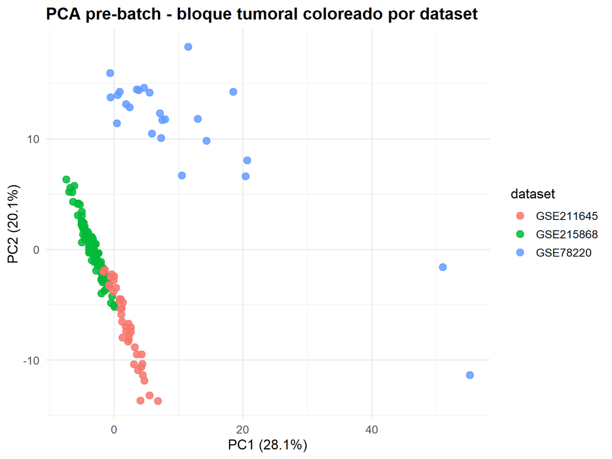

```r
pca_pre <- run_pca(expr_filt, coldata)

p_pre_dataset <- plot_pca(
  pca_pre$pca_df,
  pca_pre$var_exp,
  "dataset",
  "PCA pre-batch - bloque tumoral coloreado por dataset"
)

p_pre_platform <- plot_pca(
  pca_pre$pca_df,
  pca_pre$var_exp,
  "platform",
  "PCA pre-batch - bloque tumoral coloreado por plataforma"
)

p_pre_response <- plot_pca(
  pca_pre$pca_df,
  pca_pre$var_exp,
  "response_binary",
  "PCA pre-batch - bloque tumoral coloreado por respuesta"
)

p_pre_dataset
```

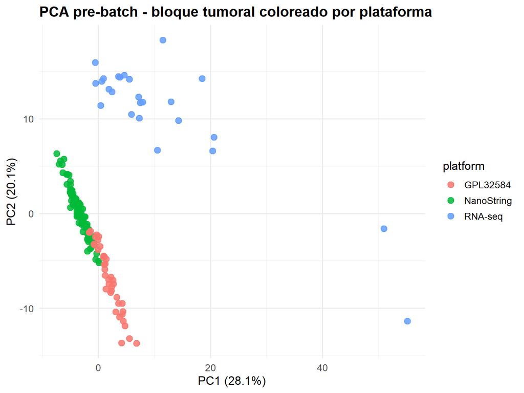

```r
p_pre_platform
```

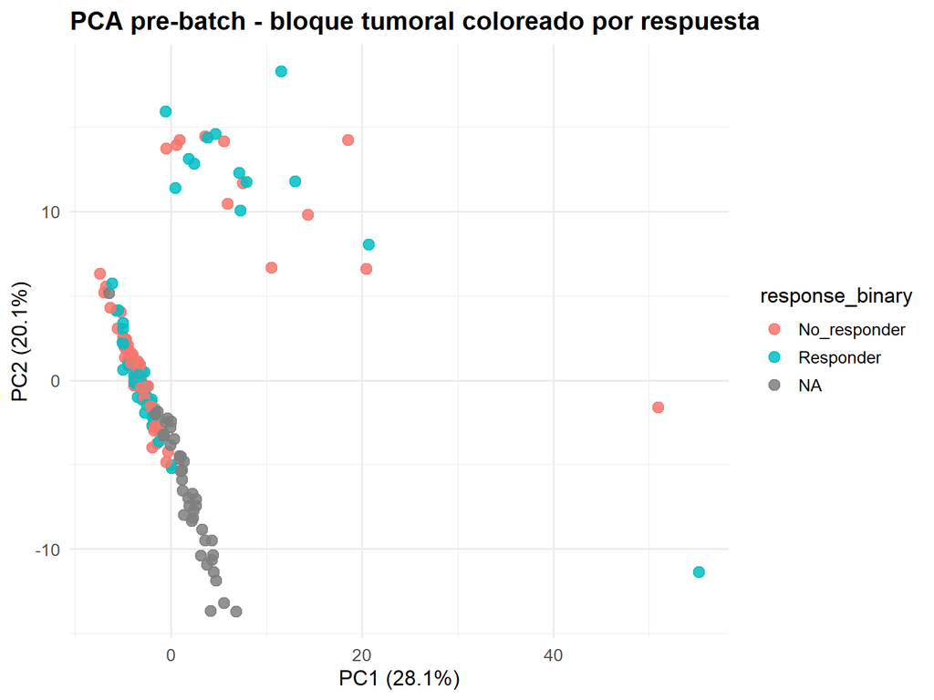

```r
p_pre_response
```

# 8 Corrección de batch effect con limma

```r
batch <- coldata$dataset

if (any(is.na(batch))) {
  stop("La variable dataset contiene NA. No se puede usar como batch sin corregir.")
}

batch <- factor(batch)

table(batch)
```

```
## batch
## GSE211645 GSE215868  GSE78220
##        40       105        25
```

```r
response_for_design <- as.character(coldata$response_binary)
response_for_design[is.na(response_for_design) | trimws(response_for_design) == ""] <- "Unknown_response"
response_for_design <- factor(response_for_design)

# removeBatchEffect no acepta NA en el diseno. Para conservar todas las
# muestras y proteger la senal de respuesta, los NA se agrupan como
# Unknown_response en vez de eliminarse o usar solo intercepto.
if (nlevels(response_for_design) > 1) {
  design <- model.matrix(~ response_for_design)
  correction_note <- paste0(
    "Se protegio response_binary en el diseno de removeBatchEffect. ",
    "Las muestras con respuesta no disponible se codificaron como Unknown_response."
  )
} else {
  design <- matrix(1, nrow = ncol(expr_filt), ncol = 1)
  colnames(design) <- "Intercept"
  correction_note <- "No hay variacion util en response_binary; se uso un diseno con intercepto."
}

correction_note
```

```
## [1] "Se protegio response_binary en el diseno de removeBatchEffect. Las muestras con respuesta no disponible se codificaron como Unknown_response."
```

```r
table(response_for_design)
```

```
## response_for_design
##     No_responder        Responder Unknown_response
##               71               58               41
```

```r
head(design)
```

```
##   (Intercept) response_for_designResponder response_for_designUnknown_response
## 1           1                            0                                   0
## 2           1                            1                                   0
## 3           1                            1                                   0
## 4           1                            1                                   0
## 5           1                            1                                   0
## 6           1                            0                                   0
```

```r
expr_batch_corrected <- limma::removeBatchEffect(
  expr_filt,
  batch = batch,
  design = design
)

dim(expr_batch_corrected)
```

```
## [1] 200 170
```

```r
stopifnot(identical(dim(expr_batch_corrected), dim(expr_filt)))
stopifnot(identical(rownames(expr_batch_corrected), rownames(expr_filt)))
stopifnot(identical(colnames(expr_batch_corrected), colnames(expr_filt)))
```

# 9 PCA post-batch

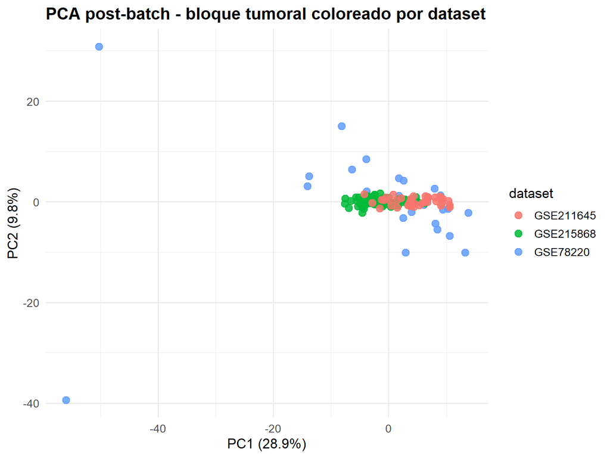

```r
pca_post <- run_pca(expr_batch_corrected, coldata)

p_post_dataset <- plot_pca(
  pca_post$pca_df,
  pca_post$var_exp,
  "dataset",
  "PCA post-batch - bloque tumoral coloreado por dataset"
)

p_post_platform <- plot_pca(
  pca_post$pca_df,
  pca_post$var_exp,
  "platform",
  "PCA post-batch - bloque tumoral coloreado por plataforma"
)

p_post_response <- plot_pca(
  pca_post$pca_df,
  pca_post$var_exp,
  "response_binary",
  "PCA post-batch - bloque tumoral coloreado por respuesta"
)

p_post_dataset
```

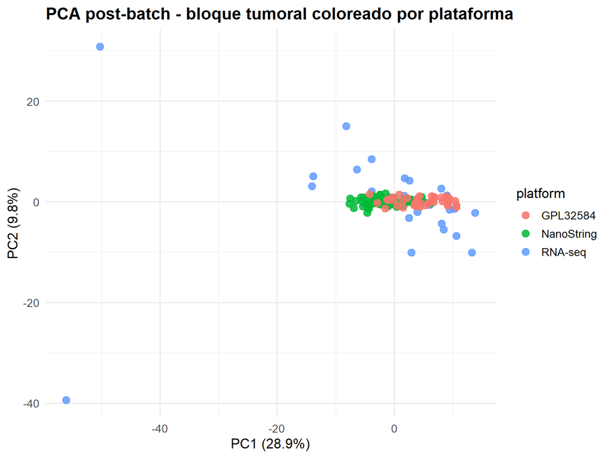

```r
p_post_platform
```

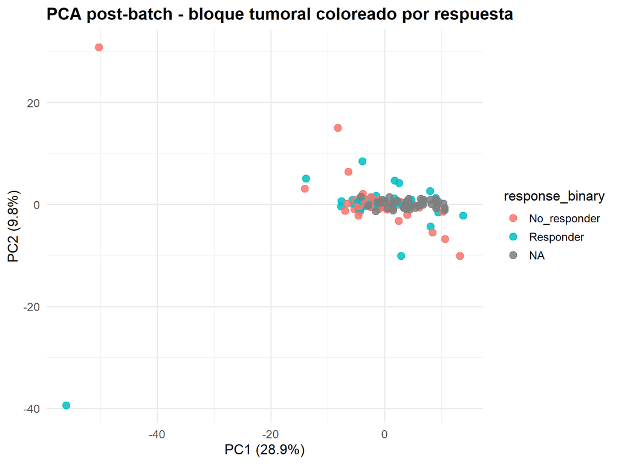

```r
p_post_response
```

# 10 Comparación pre vs post

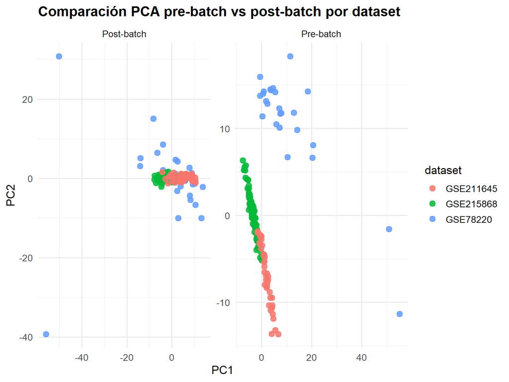

```r
pca_pre_df <- pca_pre$pca_df %>%
  mutate(stage = "Pre-batch")

pca_post_df <- pca_post$pca_df %>%
  mutate(stage = "Post-batch")

pca_compare <- bind_rows(
  pca_pre_df,
  pca_post_df
)

ggplot(pca_compare, aes(x = PC1, y = PC2, color = dataset)) +
  geom_point(size = 2.8, alpha = 0.85) +
  facet_wrap(~ stage, scales = "free") +
  labs(
    title = "Comparación PCA pre-batch vs post-batch por dataset",
    x = "PC1",
    y = "PC2",
    color = "dataset"
  ) +
  theme_minimal(base_size = 13) +
  theme(
    plot.title = element_text(face = "bold"),
    legend.position = "right"
  )
```

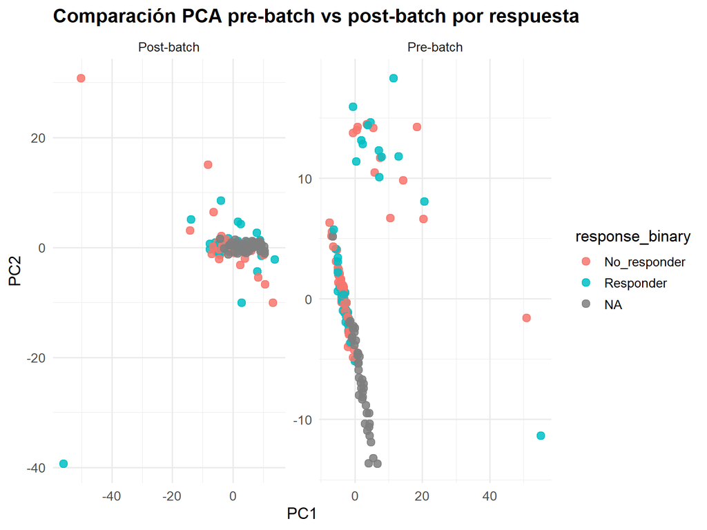

```r
ggplot(pca_compare, aes(x = PC1, y = PC2, color = response_binary)) +
  geom_point(size = 2.8, alpha = 0.85) +
  facet_wrap(~ stage, scales = "free") +
  labs(
    title = "Comparación PCA pre-batch vs post-batch por respuesta",
    x = "PC1",
    y = "PC2",
    color = "response_binary"
  ) +
  theme_minimal(base_size = 13) +
  theme(
    plot.title = element_text(face = "bold"),
    legend.position = "right"
  )
```

# 11 Varianza explicada

```r
variance_df <- tibble(
  PC = paste0("PC", seq_along(pca_pre$var_exp)),
  pre_batch = pca_pre$var_exp,
  post_batch = pca_post$var_exp
) %>%
  slice(1:min(10, n()))

variance_df %>%
  kable(
    digits = 2,
    caption = "Porcentaje de varianza explicada por los primeros componentes principales"
  )
```

Porcentaje de varianza explicada por los primeros componentes principales

| PC | pre_batch | post_batch |
| --- | --- | --- |
| PC1 | 28.09 | 28.95 |
| PC2 | 20.06 | 9.80 |
| PC3 | 8.13 | 8.46 |
| PC4 | 6.48 | 5.34 |
| PC5 | 3.45 | 4.56 |
| PC6 | 3.31 | 3.96 |
| PC7 | 2.94 | 3.67 |
| PC8 | 2.57 | 3.31 |
| PC9 | 2.13 | 2.78 |
| PC10 | 2.03 | 2.44 |

# 12 Guardado de resultados

```r
output_dir <- file.path(project_root, "resultados", "batch_correction_geo_tumor")
dir.create(output_dir, recursive = TRUE, showWarnings = FALSE)

# Guardar matriz corregida
saveRDS(
  expr_batch_corrected,
  file = file.path(output_dir, "expr_geo_tumor_batch_corrected_limma.rds")
)

# Añadir assay corregido al SummarizedExperiment.
# Primero creamos una matriz con todas las filas originales.
expr_corrected_full <- matrix(
  NA_real_,
  nrow = nrow(se_tumor),
  ncol = ncol(se_tumor),
  dimnames = list(rownames(se_tumor), colnames(se_tumor))
)

expr_corrected_full[rownames(expr_batch_corrected), colnames(expr_batch_corrected)] <- expr_batch_corrected

assay(se_tumor, "expr_batch_corrected_limma") <- expr_corrected_full

saveRDS(
  se_tumor,
  file = file.path(output_dir, "se_integrated_geo_tumor_batch_corrected_limma.rds")
)

# Guardar objetos PCA
saveRDS(
  pca_pre$pca,
  file = file.path(output_dir, "pca_pre_batch_geo_tumor.rds")
)

saveRDS(
  pca_post$pca,
  file = file.path(output_dir, "pca_post_batch_geo_tumor_limma.rds")
)

# Guardar dataframes PCA
saveRDS(
  pca_pre$pca_df,
  file = file.path(output_dir, "pca_pre_batch_geo_tumor_scores.rds")
)

saveRDS(
  pca_post$pca_df,
  file = file.path(output_dir, "pca_post_batch_geo_tumor_scores.rds")
)

list.files(output_dir, full.names = TRUE)
```

```
## [1] "C:/Users/sonia/Desktop/2_TFM_MELANOMA/resultados/batch_correction_geo_tumor/expr_geo_tumor_batch_corrected_limma.rds"
## [2] "C:/Users/sonia/Desktop/2_TFM_MELANOMA/resultados/batch_correction_geo_tumor/pca_post_batch_geo_tumor_limma.rds"
## [3] "C:/Users/sonia/Desktop/2_TFM_MELANOMA/resultados/batch_correction_geo_tumor/pca_post_batch_geo_tumor_scores.rds"
## [4] "C:/Users/sonia/Desktop/2_TFM_MELANOMA/resultados/batch_correction_geo_tumor/pca_pre_batch_geo_tumor.rds"
## [5] "C:/Users/sonia/Desktop/2_TFM_MELANOMA/resultados/batch_correction_geo_tumor/pca_pre_batch_geo_tumor_scores.rds"
## [6] "C:/Users/sonia/Desktop/2_TFM_MELANOMA/resultados/batch_correction_geo_tumor/se_integrated_geo_tumor_batch_corrected_limma.rds"
```

# 13 Checklist final

```r
checks <- tibble(
  comprobacion = c(
    "Objeto tumoral cargado como SummarizedExperiment",
    "Assay de expresión seleccionado",
    "Matriz de expresión numérica",
    "Genes con NA excluidos para PCA/corrección",
    "Genes con varianza cero excluidos",
    "Variable batch disponible",
    "Corrección con limma::removeBatchEffect ejecutada",
    "Dimensiones conservadas tras corrección",
    "PCA pre-batch calculado",
    "PCA post-batch calculado",
    "Objeto corregido guardado"
  ),
  resultado = c(
    inherits(se_tumor, "SummarizedExperiment"),
    selected_assay %in% assayNames(se_tumor),
    is.numeric(expr_filt),
    sum(na_genes) >= 0,
    sum(zero_var_genes) >= 0,
    exists("batch") && !any(is.na(batch)),
    exists("expr_batch_corrected"),
    identical(dim(expr_batch_corrected), dim(expr_filt)),
    exists("pca_pre"),
    exists("pca_post"),
    file.exists(file.path(output_dir, "se_integrated_geo_tumor_batch_corrected_limma.rds"))
  )
)

checks %>%
  kable(caption = "Checklist final de corrección batch y PCA post-batch")
```

Checklist final de corrección batch y PCA post-batch

| comprobacion | resultado |
| --- | --- |
| Objeto tumoral cargado como SummarizedExperiment | TRUE |
| Assay de expresión seleccionado | TRUE |
| Matriz de expresión numérica | TRUE |
| Genes con NA excluidos para PCA/corrección | TRUE |
| Genes con varianza cero excluidos | TRUE |
| Variable batch disponible | TRUE |
| Corrección con limma::removeBatchEffect ejecutada | TRUE |
| Dimensiones conservadas tras corrección | TRUE |
| PCA pre-batch calculado | TRUE |
| PCA post-batch calculado | TRUE |
| Objeto corregido guardado | TRUE |

# 14 Conclusión

Este documento genera una corrección exploratoria del efecto batch en el bloque tumoral GEO mediante `limma::removeBatchEffect`.

La comparación entre PCA pre-batch y post-batch permite evaluar si la agrupación por cohorte/plataforma disminuye tras la corrección. Esta evaluación es importante antes de continuar con:

- análisis diferencial entre respondedores y no respondedores,
- selección de genes candidatos,
- modelos predictivos,
- y análisis de robustez comparando resultados con y sin corrección.

La matriz corregida se guarda como `expr_batch_corrected_limma` dentro de un nuevo objeto `SummarizedExperiment`, además de guardarse como matriz independiente.